# Search for loci impactful to the %expanded phenotype

Part 2 - visualize and summarise impacts

23 February 2022

```r
    # options
    knitr::opts_chunk$set(echo = TRUE)
    options(stringsAsFactors = FALSE, dplyr.summarise.inform = FALSE)

    # libraries
    library(tidyverse)
    library(cowplot)
    library(fs)
    library(qtl2)
    library(ggbeeswarm)
    library(ggforce)
    library(flextable)
    library(ggrepel)
    devtools::load_all('../BXDstrs_package/BXDstrs')
    library(DT)
    library(ggh4x)

    # directory for production plots
    plot_dir = '../finalized_figs'; dir_create(plot_dir)
```

# 1 Load data

1. Load preprocessed annotations

```r
    vep_data = readRDS('../data/analysis_cache/annot/vep_data.rds')
    tx_info                  = vep_data$tx_info
    redux_vep_annot          = vep_data$redux_vep_annot
    assoc_test               = vep_data$assoc_test
    conseq_split             = vep_data$conseq_split
    redux_vep_annot_tab_disp = vep_data$redux_vep_annot_tab_disp
    loci_gts                 = vep_data$loci_gts
    al_freq                  = vep_data$al_freq

    # get gene info
    gene_info = readRDS('../data/analysis_cache/embl_genes.rds')

    # create a function for reducing for plotting data
    reduce_for_plt = function(data) {
        data %>%
            left_join(conseq_split, by = 'Consequence') %>%
            arrange(severity) %>%
            # distinct(loc_type, chr, pos, end, SYMBOL, Feature, IMPACT, .keep_all = TRUE) %>%
            distinct(loc_type, loc_id, SYMBOL, Feature, IMPACT, .keep_all = TRUE) %>%
            arrange(IMPACT) %>%
            # distinct(loc_type, chr, pos, end, SYMBOL, Feature, .keep_all = TRUE) %>%
            # distinct(loc_type, chr, pos, end, SYMBOL, .keep_all = TRUE)
            distinct(loc_type, loc_id, SYMBOL, Feature, .keep_all = TRUE) %>%
            distinct(loc_type, loc_id, SYMBOL, .keep_all = TRUE)
    }
```

# 2 Genes related to DNA repair

```r
    dna_repair_genes = c('Xrcc4', 'Ssbp2', 'Msh3', 'Ccnh', 'Atg10')
```

# 3 Data filters

These are the filters that are used at various points on variant/feature pairs. Also define filter thresholds here.

1. `filter1`: variants overlapping protein coding genes
2. `filter2`: variants segregating

Old filters not in use:

1. `filter3`: `BIOTYPE == 'protein_coding'`
   - These removes all regulatory features
2. `filter4`:
   - `IMPACT %in% c('HIGH', 'MODERATE', 'LOW')` |
   - `IMPACT == 'MODIFIER' & (!Consequence %in% c('intron_variant', 'intron_variant,non_coding_transcript_variant', 'intron_variant,NMD_transcript_variant'))`
3. `filter5`: `IMPACT %in% c('HIGH', 'MODERATE', 'LOW')`

```r
    # desel_conseq = c('intron_variant', 'intron_variant,non_coding_transcript_variant', 'intron_variant,NMD_transcript_variant')
    lod_thresh = -log10(0.0005)
    nonmaj_af_thresh = 0.15
```

# 4 Visualize association testing results

## 4.1 p-val by non-major allele frequency and impact & variant-type

1. `filter1 & filter2`
2. Top IMPACT per variant/gene
3. Of interest are loci strongly associated with %expanded phenotype and reasonable non-major allele frequency

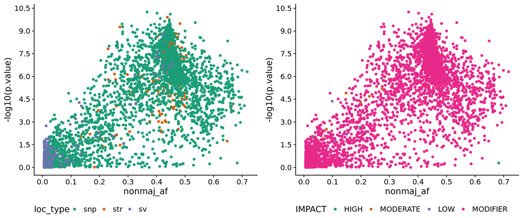

```r
    # NOTE: need to first filter, then take effect with highest impact, not other way around
    to_plt = redux_vep_annot %>%
        # old filter
        # filter(IMPACT %in% c('HIGH', 'MODERATE', 'LOW') |
        #      ( IMPACT == 'MODIFIER' & (!Consequence %in% desel_conseq) )) %>%
        reduce_for_plt %>%
        # arrange(IMPACT) %>%
        # distinct(loc_type, chr, pos, end, SYMBOL, .keep_all = TRUE) %>%
        # left_join(assoc_test, by = c('loc_type', 'chr', 'pos', 'end')) %>%
        left_join(assoc_test, by = c('loc_type', 'loc_id')) %>%
        filter(!is.na(p.value))

    # check for missing values
    # to_plt %>% count(is.na(nonmaj_af), is.na(p.value), is.na(IMPACT), is.na(Consequence))

    p1 = to_plt %>%
        ggplot(aes(nonmaj_af, -log10(p.value), color = loc_type)) +
        geom_point() +
        scale_color_brewer(palette = 'Dark2') +
        scale_x_continuous(breaks = scales::breaks_width(width = 0.1)) +
        scale_y_continuous(breaks = scales::breaks_width(width = 1.5)) +
        theme_half_open() +
        theme(legend.position = 'bottom')
    p2 = to_plt %>%
        ggplot(aes(nonmaj_af, -log10(p.value), color = IMPACT)) +
        geom_point() +
        scale_color_brewer(palette = 'Dark2') +
        scale_x_continuous(breaks = scales::breaks_width(width = 0.1)) +
        scale_y_continuous(breaks = scales::breaks_width(width = 1.5)) +
        theme_half_open() +
        theme(legend.position = 'bottom')
    p = plot_grid(p1, p2, nrow = 1)
    p
```

```r
    ggsave('test.pdf', p, w = 12, h = 5)
```

## 4.2 p-val by gene position

1. `filter1 & filter2`
2. Top IMPACT per variant/gene

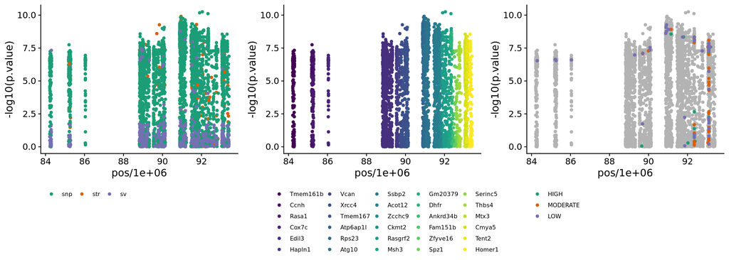

```r
    to_plt = redux_vep_annot %>%
        # old filter
        # filter(IMPACT %in% c('HIGH', 'MODERATE', 'LOW') |
        #      ( IMPACT == 'MODIFIER' & (!Consequence %in% desel_conseq) )) %>%
        reduce_for_plt %>%
        # arrange(IMPACT) %>%
        # distinct(loc_type, chr, pos, end, SYMBOL, .keep_all = TRUE) %>%
        # left_join(assoc_test, by = c('loc_type', 'chr', 'pos', 'end')) %>%
        left_join(assoc_test, by = c('loc_type', 'loc_id')) %>%
        filter(!is.na(p.value)) %>%
        mutate(pass_filter = -log10(p.value) >= lod_thresh & nonmaj_af >= nonmaj_af_thresh)

    gene_ord = gene_info %>% arrange(gene_pos) %>% pull(gene_name) %>% keep(~.x %in% (to_plt %>% pull(SYMBOL) %>% unique))
    p_base = to_plt %>%
        mutate(SYMBOL = fct_relevel(SYMBOL, gene_ord)) %>%
        ggplot() +
        theme_half_open() +
        theme(legend.position = 'bottom',
              legend.text = element_text(size = 8))
    p1 = p_base +
        # geom_point(data = ~.x %>% filter(!pass_filter),
        #      aes(pos/1e6, -log10(p.value)), color = 'gray70') +
        # geom_point(data = ~.x %>% filter(pass_filter),
        #      aes(pos/1e6, -log10(p.value), color = loc_type)) +
        geom_point(aes(pos/1e6, -log10(p.value), color = loc_type)) +
        scale_color_brewer(palette = 'Dark2', na.value = 'gray70', guide = guide_legend(title = NULL))
    p2 = p_base +
        # geom_point(data = ~.x %>% filter(!pass_filter),
        #      aes(pos/1e6, -log10(p.value)), color = 'gray70') +
        # geom_point(data = ~.x %>% filter(pass_filter),
        #      aes(pos/1e6, -log10(p.value), color = SYMBOL)) +
        geom_point(aes(pos/1e6, -log10(p.value), color = SYMBOL)) +
        scale_color_viridis_d(na.value = 'gray70', guide = guide_legend(title = NULL))
    p3 = p_base +
        geom_point(data = ~.x %>% filter(IMPACT == 'MODIFIER'),
               aes(pos/1e6, -log10(p.value)), color = 'gray70') +
        geom_point(data = ~.x %>% filter(IMPACT != 'MODIFIER'),
               aes(pos/1e6, -log10(p.value), color = IMPACT)) +
        # geom_point(aes(pos/1e6, -log10(p.value), color = IMPACT)) +
        # scale_color_viridis_d(na.value = 'gray70')
        scale_color_brewer(palette = 'Dark2', guide = guide_legend(ncol = 1, title = NULL))
    p = plot_grid(p1, p2, p3, nrow = 1, axis = 'tb', align = 'h')
    p
```

```r
    ggsave('test.pdf', p, w = 14, h = 5)
```

## 4.3 p-val by gene and position

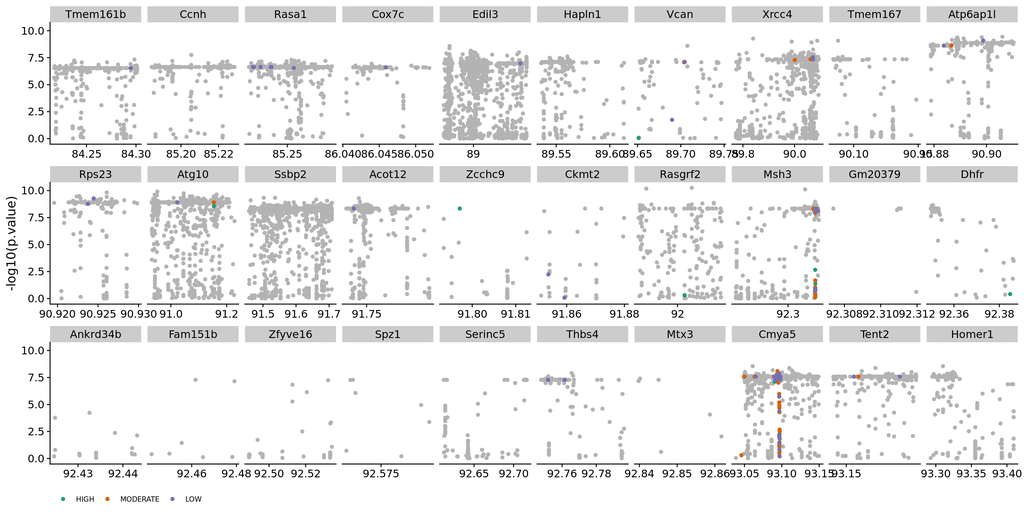

```r
    gene_ord = gene_info %>% arrange(gene_pos) %>% pull(gene_name) %>% keep(~.x %in% (to_plt %>% pull(SYMBOL) %>% unique))
    p = to_plt %>%
        mutate(SYMBOL = fct_relevel(SYMBOL, gene_ord)) %>%
        ggplot() +
        geom_point(data = ~.x %>% filter(IMPACT == 'MODIFIER'),
               aes(pos/1e6, -log10(p.value)), color = 'gray70') +
        geom_point(data = ~.x %>% filter(IMPACT != 'MODIFIER'),
               aes(pos/1e6, -log10(p.value), color = IMPACT)) +
        scale_x_continuous(breaks = scales::pretty_breaks(n = 2)) +
        scale_color_brewer(palette = 'Dark2', guide = guide_legend(nrow = 1, title = NULL)) +
        facet_wrap(~SYMBOL, scales = 'free_x', nrow = 3) +
        theme_half_open() +
        theme(legend.position = 'bottom',
              legend.text = element_text(size = 8),
              axis.title.x = element_blank()
        )
    p
```

```r
    ggsave('test.pdf', p, w = 14, h = 10)
```

# 5 Numeric summaries

## 5.1 Locus counts

1. `filter1 & filter2`: in region of interest, overlapping protein coding genes and segregating
2. Table values are variant counts

```r
    smry = loci_gts %>%
        filter(!is.na(GT_A)) %>%
        # distinct(loc_type, chr, pos, end) %>%
        distinct(loc_type, loc_id) %>%
        left_join(assoc_test %>%
                filter(!is.na(p.value)) %>%
                # mutate(assoc_tested = TRUE), by = c('loc_type', 'chr', 'pos', 'end')) %>%
                mutate(assoc_tested = TRUE), by = c('loc_type', 'loc_id')) %>%
        mutate(assoc_tested = replace_na(assoc_tested, FALSE)) %>%
        count(loc_type, assoc_tested) %>%
        pivot_wider(id_cols = loc_type, names_from = assoc_tested, values_from = n, names_prefix = 'assoc_test_', values_fill = list(n = 0))
    smry %>%
        add_row(smry %>% summarise(across(matches('assoc_test_'), sum, na.rm = TRUE))) %>%
        mutate(tot = assoc_test_TRUE + assoc_test_FALSE)
```

| loc_type | assoc_test_TRUE | assoc_test_FALSE | tot |
| --- | --- | --- | --- |
| snp | 9103 | 0 | 9103 |
| str | 160 | 0 | 160 |
| sv | 959 | 24 | 983 |
| NA | 10222 | 24 | 10246 |

## 5.2 Features per gene

1. `filter1 & filter2`

```r
    feats_per_gene = function(data, loc_types = c('str', 'snp', 'sv')) {
        data %>%
            filter(loc_type %in% loc_types) %>%
            distinct(SYMBOL, Feature_type, Feature) %>%
            count(SYMBOL, Feature_type) %>%
            group_by(Feature_type) %>%
            skimr::skim(n) %>%
            as_tibble %>%
            select(skim_variable, Feature_type, matches('numeric')) %>%
            rename_with(cols = matches('numeric'), .fn = ~str_replace(.x, 'numeric.', ''))
    }
```

```r
    feats_per_gene(redux_vep_annot)
```

| skim_variable | Feature_type | mean | sd | p0 | p25 | p50 | p75 | p100 | hist |
| --- | --- | --- | --- | --- | --- | --- | --- | --- | --- |
| n | RegulatoryFeature | 9.730769 | 10.626599 | 1 | 3.00 | 6.5 | 13.50 | 52 | ▇▂▁▁▁ |
| n | Transcript | 4.866667 | 3.636343 | 1 | 2.25 | 3.5 | 6.75 | 15 | ▇▃▂▂▁ |

## 5.3 Feature counts

1. `filter1 & filter2`

```r
    feat_counts = function(data, loc_types = c('str', 'snp', 'sv')) {
        data %>%
            filter(loc_type %in% loc_types) %>%
            distinct(Feature_type, Feature) %>%
            count(Feature_type)
    }
```

```r
    smry = feat_counts(redux_vep_annot)
    smry %>% add_row(smry %>% summarise(n = sum(n)))
```

| Feature_type | n |
| --- | --- |
| RegulatoryFeature | 252 |
| Transcript | 146 |
| NA | 398 |

## 5.4 Feature/variant pair counts

1. `filter1 & filter2`
2. Have not reduced to a single IMPACT/Consequence per Feature
3. Both `filter3` and `filter4` are no longer in use, so just one value

```r
    pair_count_smry = function(data, loc_types = c('str', 'snp', 'sv')) {
        smry = list(
            all_feature_variant_pairs = data %>%
                # semi_join(assoc_test %>% filter(!is.na(p.value)), by = c('loc_type', 'chr', 'pos', 'end')),
                semi_join(assoc_test %>% filter(!is.na(p.value)), by = c('loc_type', 'loc_id')),
            impact_conseq_biotype_filt_pairs = data %>%
                # semi_join(assoc_test %>% filter(!is.na(p.value)), by = c('loc_type', 'chr', 'pos', 'end')) %>%
                semi_join(assoc_test %>% filter(!is.na(p.value)), by = c('loc_type', 'loc_id')) # %>%
                # filter(IMPACT %in% c('HIGH', 'MODERATE', 'LOW') |
                #      ( IMPACT == 'MODIFIER' & (!Consequence %in% desel_conseq) )) %>%
                # old filter
                # filter(BIOTYPE == 'protein_coding')
        ) %>% map_df(~.x, .id = 'list') %>%
            filter(loc_type %in% loc_types) %>%
            count(list)
        smry
    }
```

```r
    pair_count_smry(redux_vep_annot)
```

| list | n |
| --- | --- |
| all_feature_variant_pairs | 44493 |
| impact_conseq_biotype_filt_pairs | 44493 |

## 5.5 Proportion of variants above/below allele frequency threshold

1. `filter1 & filter2`
2. Means we took variant/feature pairs and filtered, then calculate proportion from these variants

```r
    prop_pass = function(data, loc_types = c('str', 'snp', 'sv')) {
        redux_vep_annot %>%
            filter(loc_type %in% loc_types) %>%
            # inner_join(assoc_test %>% filter(!is.na(p.value)), by = c('loc_type', 'chr', 'pos', 'end')) %>%
            inner_join(assoc_test %>% filter(!is.na(p.value)), by = c('loc_type', 'loc_id')) %>%
            # old filter
            # filter(IMPACT %in% c('HIGH', 'MODERATE', 'LOW') |
            #    ( IMPACT == 'MODIFIER' & (!Consequence %in% desel_conseq) )) %>%
            # old filter
            # filter(BIOTYPE == 'protein_coding') %>%
            # distinct(loc_type, chr, pos, end, nonmaj_af) %>%
            distinct(loc_type, loc_id, nonmaj_af) %>%
            mutate(rare = nonmaj_af < nonmaj_af_thresh) %>%
            count(rare) %>%
            mutate(tot = sum(n), prop = n/tot)
    }
```

```r
    prop_pass(redux_vep_annot)
```

| rare | n | tot | prop |
| --- | --- | --- | --- |
| FALSE | 8397 | 10222 | 0.8214635 |
| TRUE | 1825 | 10222 | 0.1785365 |

# 6 Supplementary figure VARSEL

1. `filter1 & filter2`
2. LOD and non-major allele thresholds shown
3. Rare variants (< non-major al freq thresh) as hollow shapes

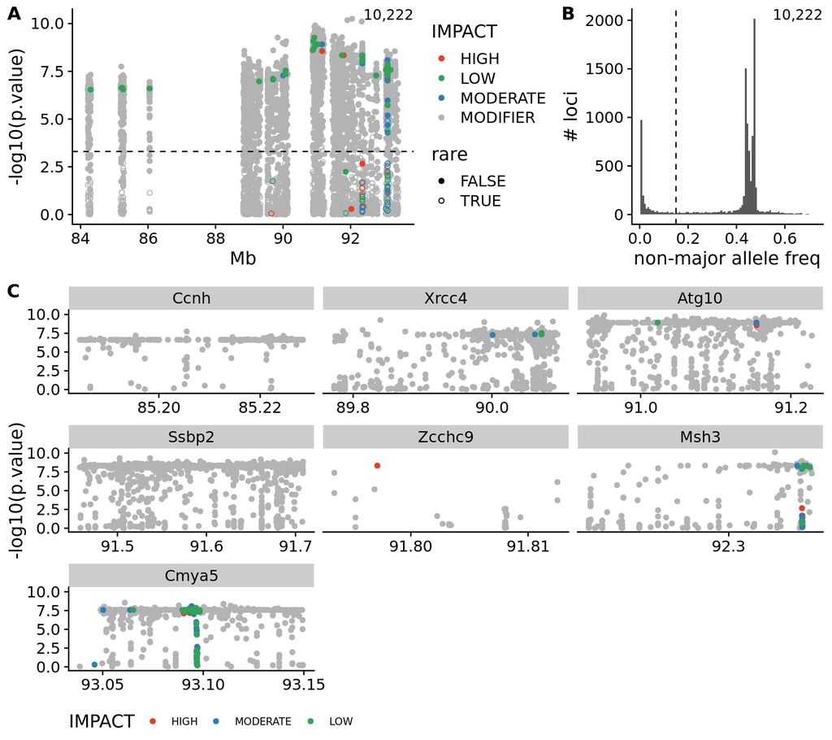

```r
    loc_types = c('str', 'snp', 'sv')
    to_plt = redux_vep_annot %>%
        filter(loc_type %in% loc_types) %>%
        # old filter
        # filter(IMPACT %in% c('HIGH', 'MODERATE', 'LOW') |
        #    ( IMPACT == 'MODIFIER' & (!Consequence %in% desel_conseq) )) %>%
        # old filter
        # filter(BIOTYPE == 'protein_coding') %>%
        reduce_for_plt %>%
        # arrange(IMPACT) %>%
        # distinct(loc_type, chr, pos, end, SYMBOL, .keep_all = TRUE) %>%
        # left_join(assoc_test, by = c('loc_type', 'chr', 'pos', 'end')) %>%
        left_join(assoc_test, by = c('loc_type', 'loc_id')) %>%
        filter(!is.na(p.value)) %>%
        mutate(pass_filter = -log10(p.value) >= lod_thresh & nonmaj_af >= nonmaj_af_thresh)
    p1 = to_plt %>%
        mutate(rare = nonmaj_af < nonmaj_af_thresh) %>%
        ggplot(aes(pos/1e6, -log10(p.value), color = IMPACT, shape = rare)) +
        geom_point(data = ~.x %>% filter(IMPACT == 'MODIFIER')) + # make sure the MODIFIER points are underneath the other effects
        geom_point(data = ~.x %>% filter(IMPACT != 'MODIFIER')) +
        geom_hline(yintercept = lod_thresh, linetype = 'dashed') +
        # geom_text(data = ~tibble(n = .x %>% distinct(loc_type, chr, pos, end) %>% nrow),
        geom_text(data = ~tibble(n = .x %>% distinct(loc_type, loc_id) %>% nrow),
              aes(label = scales::comma(n)), x = Inf, y = Inf, hjust = 'inward', vjust = 'inward', inherit.aes = FALSE) +
        scale_color_manual(values = c('HIGH' = '#f03b20', 'MODERATE' = '#2c7fb8' , 'LOW' = '#31a354', 'MODIFIER' = 'gray70')) +
        scale_shape_manual(values = c(`TRUE` = 1, `FALSE` = 19)) +
        theme_half_open() +
        theme(legend.position = 'right',
          panel.spacing = unit(0, 'lines')) +
        labs(x = 'Mb')
    p2 = al_freq %>%
        # semi_join(to_plt, by = c('loc_type', 'chr', 'pos', 'end')) %>%
        semi_join(to_plt, by = c('loc_type', 'loc_id')) %>%
        ggplot(aes(nonmaj_af)) +
        geom_histogram(position = 'stack', bins = 100) +
        geom_vline(xintercept = 0.15, linetype = 'dashed') +
        # geom_text(data = ~tibble(n = .x %>% distinct(loc_type, chr, pos, end) %>% nrow),
        geom_text(data = ~tibble(n = .x %>% distinct(loc_type, loc_id) %>% nrow),
              aes(label = scales::comma(n)), x = Inf, y = Inf, hjust = 'inward', vjust = 'inward') +
        theme_half_open() +
        labs(x = 'non-major allele freq', y = '# loci')
    p3 = to_plt %>%
        mutate(SYMBOL = fct_relevel(SYMBOL, gene_ord)) %>%
        filter(SYMBOL %in% c('Msh3', 'Atg10', 'Ssbp2', 'Xrcc4', 'Ccnh', 'Cmya5', 'Zcchc9')) %>%
        ggplot() +
        geom_point(data = ~.x %>% filter(IMPACT == 'MODIFIER'),
               aes(pos/1e6, -log10(p.value)), color = 'gray70') +
        geom_point(data = ~.x %>% filter(IMPACT != 'MODIFIER'),
               aes(pos/1e6, -log10(p.value), color = IMPACT)) +
        scale_x_continuous(breaks = scales::pretty_breaks(n = 2)) +
        scale_color_manual(values = c('HIGH' = '#f03b20', 'MODERATE' = '#2c7fb8' , 'LOW' = '#31a354', 'MODIFIER' = 'gray70')) +
        facet_wrap(~SYMBOL, scales = 'free_x', nrow = 3) +
        theme_half_open() +
        theme(legend.position = 'bottom',
              legend.text = element_text(size = 8),
              axis.title.x = element_blank()
        )
    p = plot_grid(
        plot_grid(p1, p2, nrow = 1, rel_widths = c(1, 0.5), axis = 'bt', align = 'h', labels = c('A', 'B')),
        p3, ncol = 1, rel_heights = c(0.6, 1), labels = c('', 'C')
    )
    p
```

```r
    ggsave('test.pdf', p, w = 9, h = 8)

    #
    ggsave(path(plot_dir, 'Suppl_Fig_6.pdf'), p, w = 9, h = 8)
```

# 7 Supp. Table/Figure SNPSCAN

1. `filter1 & filter2`
2. Plus:
   - `PASS_FILTER` LOD thresh
   - `PASS_FILTER` non-major al freq thresh

```r
    # data = redux_vep_annot
    var_scan_tbl = function(data, loc_types = c('str', 'snp', 'sv')) {
        # take the top impact per variant/gene combination
        to_disp = data %>%
            filter(loc_type %in% loc_types) %>%
            # old filter
            # filter(IMPACT %in% c('HIGH', 'MODERATE', 'LOW') |
            #    ( IMPACT == 'MODIFIER' & (!Consequence %in% desel_conseq) )) %>%
            # filter(IMPACT %in% c('HIGH', 'MODERATE', 'LOW')) %>%
            # old filter
            # filter(BIOTYPE == 'protein_coding') %>%
            reduce_for_plt %>%
            # arrange(IMPACT) %>%
            # distinct(loc_type, chr, pos, end, SYMBOL, .keep_all = TRUE) %>%
            # left_join(assoc_test, by = c('loc_type', 'chr', 'pos', 'end')) %>%
            left_join(assoc_test, by = c('loc_type', 'loc_id')) %>%
            filter(!is.na(p.value)) %>%
            mutate(pass_filter = -log10(p.value) >= lod_thresh & nonmaj_af >= nonmaj_af_thresh) %>%
            # left_join(conseq_split, by = 'Consequence') %>%
            filter(pass_filter)

        # table view
        ft_headers = to_disp %>%
            distinct(IMPACT, severity, top_csq) %>%
            unite('col_keys', c('IMPACT', 'top_csq'), remove = FALSE) %>%
            relocate(col_keys, .before = 1) %>%
            arrange(IMPACT, severity) %>%
            mutate_all(as.character) %>%
            select(!severity) %>%
            set_names(c('col_keys', 'line1', 'line2'))
        ft = to_disp %>%
            count(SYMBOL, IMPACT, top_csq) %>%
            complete(SYMBOL = data %>% pull(SYMBOL) %>% unique) %>%
            pivot_wider(id_cols = SYMBOL, names_from = c(IMPACT, top_csq), values_from = n) %>%
            select(SYMBOL, all_of(ft_headers %>% pull(col_keys)))
        ft = ft %>%
            rowwise %>%
            mutate(
                   n_high_vars = sum(c_across(matches('^(HIGH)')), na.rm = TRUE),
                   n_nonmod_vars = sum(c_across(matches('^(HIGH|MODERATE|LOW)')), na.rm = TRUE),
                   n_vars = sum(c_across(!SYMBOL), na.rm = TRUE)) %>%
            ungroup %>%
            arrange(desc(n_nonmod_vars, n_high_vars, n_vars)) %>%
            left_join(gene_info %>% select(gene_name, gene_descr), by = c('SYMBOL' = 'gene_name')) %>%
            select(!n_vars) %>%
            mutate(across(matches('n_'), ~if_else(.x == 0, '', as.character(.x))))
        hlight_rows = ft %>% pull(SYMBOL) %>% str_which(str_c(dna_repair_genes, collapse = '|'))
        bg_col = '#9ecae1'
        ft = ft %>% mutate(row = 1:n()) %>% relocate(row, .before = 1)
        ft_obj = ft %>%
            flextable %>%
            set_header_df(mapping = ft_headers %>%
                        add_row(col_keys = 'n_high_vars', line1 = NA, line2 = '# high impact variants') %>%
                        add_row(col_keys = 'n_nonmod_vars', line1 = NA, line2 = '# non-modifier impact variants') %>%
                        add_row(col_keys = 'gene_descr', line1 = NA, line2 = 'Gene description'), key = 'col_keys') %>%
            merge_h(part = "header", i = 1) %>%
            theme_box %>%
            rotate(i = 2, j = 1:(dim(ft)[2]-1), rotation = "btlr", align = 'bottom', part = "header") %>%
            align(align = "center", part = "all") %>%
            font(fontname = 'Arial', part = "all") %>%
            width(width = 0.1) %>%
            width(width = 3.5, j = ncol(ft)) %>%
            align(align = 'left', j = ncol(ft)) %>%
            valign(i = 2, j = dim(ft)[2], valign = 'bottom', part = 'header') %>%
            bg(bg = bg_col, i = hlight_rows) %>%
            # height(height = 0.1, part = 'body')
            padding(padding.top = 0.1, padding.bottom = 0.1, part = 'body')

        # final variant counts in SNPSCAN table
        smry = to_disp %>%
            distinct(SYMBOL, loc_type, chr, pos, end, IMPACT) %>%
            count(IMPACT, name = 'n_variants')
        smry = smry %>% add_row(smry %>% summarise(n_variants = sum(n_variants)))

        #
        return(list(ft_obj = ft_obj, smry = smry))
    }

    ret = var_scan_tbl(redux_vep_annot)
    ret$ft_obj
```

|  |  | HIGH frameshift_variant | HIGH stop_lost | MODERATE inframe_insertion | MODERATE inframe_deletion | MODERATE missense_variant | LOW splice_region_variant | LOW synonymous_variant | MODIFIER coding_sequence_variant | MODIFIER 5_prime_UTR_variant | MODIFIER 3_prime_UTR_variant | MODIFIER non_coding_transcript_exon_variant | MODIFIER intron_variant | MODIFIER upstream_gene_variant | MODIFIER downstream_gene_variant | # high impact variants | # non-modifier impact variants | Gene description |
| --- | --- | --- | --- | --- | --- | --- | --- | --- | --- | --- | --- | --- | --- | --- | --- | --- | --- | --- |
| 1 | Cmya5 | 2 |  | 3 | 1 | 33 |  | 25 |  |  |  |  | 543 | 13 |  | 2 | 64 | cardiomyopathy associated 5 |
| 2 | Msh3 |  |  |  | 1 | 4 | 3 | 3 |  |  | 17 | 12 | 171 |  | 2 |  | 11 | mutS homolog 3 |
| 3 | Vcan |  |  |  |  | 7 |  | 1 |  |  | 5 |  | 31 | 5 | 23 |  | 8 | versican |
| 4 | Rasa1 |  |  |  |  |  | 4 | 2 |  |  | 4 | 22 | 532 | 20 | 15 |  | 6 | RAS p21 protein activator 1 |
| 5 | Atp6ap1l |  |  |  |  | 1 |  | 4 |  |  |  |  | 145 | 29 | 26 |  | 5 | ATPase, H+ transporting, lysosomal accessory protein 1-like |
| 6 | Xrcc4 |  |  |  |  | 3 | 1 | 1 |  | 2 | 1 |  | 952 | 15 | 1 |  | 5 | X-ray repair complementing defective repair in Chinese hamster cells 4 |
| 7 | Atg10 | 1 |  |  |  | 2 |  | 1 |  |  | 6 |  | 832 | 1 | 14 | 1 | 4 | autophagy related 10 |
| 8 | Tent2 |  |  |  |  | 1 |  | 2 |  | 3 | 3 |  | 165 | 24 | 16 |  | 3 | terminal nucleotidyltransferase 2 |
| 9 | Rps23 |  |  |  |  |  | 2 |  |  | 3 | 5 | 9 | 24 | 36 | 79 |  | 2 | ribosomal protein S23 |
| 10 | Thbs4 |  |  |  |  |  |  | 2 |  |  |  |  | 76 | 1 | 16 |  | 2 | thrombospondin 4 |
| 11 | Tmem161b |  |  |  |  | 1 |  | 1 |  |  | 2 | 5 | 153 | 28 | 50 |  | 2 | transmembrane protein 161B |
| 12 | Acot12 |  |  |  |  |  |  | 1 |  |  |  |  | 208 | 16 | 3 |  | 1 | acyl-CoA thioesterase 12 |
| 13 | Cox7c |  |  |  |  |  |  | 1 |  | 9 | 1 |  | 17 | 13 | 71 |  | 1 | cytochrome c oxidase subunit 7C |
| 14 | Edil3 |  |  |  |  |  |  | 1 |  |  | 3 | 13 | 1755 | 1 | 38 |  | 1 | EGF-like repeats and discoidin I-like domains 3 |
| 15 | Zcchc9 |  | 1 |  |  |  |  |  |  |  | 1 |  |  | 2 | 3 | 1 | 1 | zinc finger, CCHC domain containing 9 |
| 16 | Ankrd34b |  |  |  |  |  |  |  |  |  |  |  | 1 | 1 |  |  |  | ankyrin repeat domain 34B |
| 17 | Ccnh |  |  |  |  |  |  |  |  |  | 13 |  | 135 | 20 | 35 |  |  | cyclin H |
| 18 | Ckmt2 |  |  |  |  |  |  |  |  |  |  |  | 5 | 2 | 1 |  |  | creatine kinase, mitochondrial 2 |
| 19 | Dhfr |  |  |  |  |  |  |  |  |  | 2 |  | 7 | 70 |  |  |  | dihydrofolate reductase |
| 20 | Fam151b |  |  |  |  |  |  |  |  |  |  |  | 2 |  |  |  |  | family with sequence similarity 151, member B |
| 21 | Gm20379 |  |  |  |  |  |  |  |  |  |  |  |  |  | 5 |  |  | predicted gene, 20379 |
| 22 | Hapln1 |  |  |  |  |  |  |  |  | 3 | 1 |  | 117 | 16 | 4 |  |  | hyaluronan and proteoglycan link protein 1 |
| 23 | Homer1 |  |  |  |  |  |  |  |  | 5 | 3 |  | 84 | 8 | 5 |  |  | homer scaffolding protein 1 |
| 24 | Mtx3 |  |  |  |  |  |  |  |  |  |  | 1 |  | 2 | 1 |  |  | metaxin 3 |
| 25 | Rasgrf2 |  |  |  |  |  |  |  |  |  | 5 |  | 139 | 5 | 2 |  |  | RAS protein-specific guanine nucleotide-releasing factor 2 |
| 26 | Serinc5 |  |  |  |  |  |  |  |  |  |  |  | 14 |  | 11 |  |  | serine incorporator 5 |
| 27 | Spz1 |  |  |  |  |  |  |  |  |  |  |  |  | 2 | 3 |  |  | spermatogenic leucine zipper 1 |
| 28 | Ssbp2 |  |  |  |  |  |  |  | 1 |  | 18 | 15 | 927 | 1 | 50 |  |  | single-stranded DNA binding protein 2 |
| 29 | Tmem167 |  |  |  |  |  |  |  |  | 5 | 6 |  | 29 | 18 | 1 |  |  | transmembrane protein 167 |
| 30 | Zfyve16 |  |  |  |  |  |  |  |  |  |  |  | 3 | 2 |  |  |  | zinc finger, FYVE domain containing 16 |

```r
    ret$smry
```

| IMPACT | n_variants |
| --- | --- |
| HIGH | 4 |
| MODERATE | 57 |
| LOW | 55 |
| MODIFIER | 8097 |
| NA | 8213 |

```r
    ret$ft_obj %>% save_as_html(path = path(plot_dir, 'Suppl_Tbl_1.html'))
```